# Session 9

## What is statsmodels?

- A library for statistical modeling, implementing standard statistical models in Python using NumPy and SciPy
- Includes:
  - Linear (regression) models of many forms
  - Descriptive statistics
  - Statistical tests
  - Time series analysis
  - and much more ...
- Statsmodels homepage:
  - http://statsmodels.sourceforge.net/
- Statsmodels support for time series:
  - http://statsmodels.sourceforge.net/stable/tsa.html
  - http://www.statsmodels.org/stable/statespace.html
- Other Packages:
  - Arch: http://arch.readthedocs.io/en/latest/index.html#
  - Prophet: https://facebook.github.io/prophet/

## Descriptive statistics

Functions

- stattools.acovf() Autocovariance for 1D
- stattools.acf() Autocorrelation function for 1d arrays.
- stattools.pacf() Partial autocorrelation estimated
- stattools.ccovf() crosscovariance for 1D
- stattools.ccf() cross-correlation function for 1d
- stattools.periodogram(X) Returns the periodogram for the natural frequency of X

## Statistical tests

- Ljung-Box test for zero autocorrelation
- Unit root test for cointegration (Augmented Dickey-Fuller test)
- Granger-causality
- Whiteness (iid-ness) and normality

Functions

- stattools.adfuller() - Augmented Dickey-Fuller unit root test
- stattools.kpss()- Kwiatkowski-Phillips-Schmidt-Shin test for stationarity.
- stattools.coint() - Test for no-cointegration of a univariate equation
- stattools.bds() - Calculate the BDS test statistic for independence of a time series
- stattools.q_stat() - Return’s Ljung-Box Q Statistic

## Estimation

- Exponential Smoothing
  - holtwinters.ExponentialSmoothing() - Holt Winter’s Exponential Smoothing
  - holtwinters.SimpleExpSmoothing() - Simple Exponential Smoothing wrapper(…)
  - holtwinters.Holt() - Holt’s Exponential Smoothing wrapper(…)
  - holtwinters.HoltWintersResults() - Holt Winter’s Exponential Smoothing Result
- Univariate Autogressive Processes (AR)
  - ar_model.AR() - Autoregressive AR(p) model
  - ar_model.ARResults() - Class to hold results from fitting an AR model.
- Autogressive Moving-Average Processes (ARMA) and Kalman Filter
  - arima_model.ARMA() - Autoregressive Moving Average ARMA(p,q) Model
  - arima_model.ARMAResults() - Class to hold results from fitting an ARMA model.
  - arima_model.ARIMA() - Autoregressive Integrated Moving Average ARIMA(p,d,q) Model
  - arima_model.ARIMAResults()
  - more in statsmodels.tsa.arima_process
- Vector Autogressive Processes (VAR)
  - vector_ar.var_model.VAR() - Fit VAR(p) process and do lag order selection
  - vector_ar.var_model.VARResults() - Estimate VAR(p) process with fixed number of lags
  - vector_ar.dynamic.DynamicVAR() - Estimates time-varying vector autoregression (VAR(p)) using equation-by-equation least squares
  - more in statsmodels.tsa.vector_ar.var_model

## Example I

###### Source: http://ucanalytics.com/blogs/wp-content/uploads/2017/08/ARIMA-TimeSeries-Analysis-of-Tractor-Sales.html#Step-1:-Visualize-Tractor-Sales-data-as-time-series

#### Step 1: Visualize Tractor Sales data as time series

```python
import pandas as pd
import numpy as np
import matplotlib.pyplot as plt

import itertools
import calendar
import sys
import warnings

from scipy.stats import boxcox

from pandas.plotting import register_matplotlib_converters
register_matplotlib_converters()

import statsmodels.api as sm
from statsmodels.tsa.stattools import acf, pacf, adfuller, kpss
from statsmodels.stats.diagnostic import acorr_ljungbox
import statsmodels.tsa.api as smt

plt.style.use('bmh')
%matplotlib inline
from IPython.core.interactiveshell import InteractiveShell
InteractiveShell.ast_node_interactivity = "all"
```

```python
## Load the dataset
Filename= 'Tractor-Sales.csv'
sales_data = pd.read_csv(Filename)
sales_data.head(5)
```

|  | Month-Year | Number of Tractor Sold |
| --- | --- | --- |
| 0 | Jan-03 | 141 |
| 1 | Feb-03 | 157 |
| 2 | Mar-03 | 185 |
| 3 | Apr-03 | 199 |
| 4 | May-03 | 203 |

```python
## Examine data types
sales_data.dtypes
```

```
Month-Year                object
Number of Tractor Sold     int64
dtype: object
```

```python
# since the complete date was not mentioned, we assume that it was the first of every month
dates = pd.date_range(start='2003-01-01', freq='MS', periods=len(sales_data))

dates[:5]

sales_data['Month'] = dates.month
sales_data['Month'] = sales_data['Month'].apply(lambda x: calendar.month_abbr[x])
sales_data['Year'] = dates.year

sales_data.drop(['Month-Year'], axis=1, inplace=True)
sales_data.rename(columns={'Number of Tractor Sold':'Tractor-Sales'}, inplace=True)
sales_data = sales_data[['Month', 'Year', 'Tractor-Sales']]

# set the dates as the index of the dataframe, so that it can be treated as a
# time-series dataframe
sales_data.set_index(dates, inplace=True)

# check out first 5 samples of the data
sales_data.head(5)
```

```
DatetimeIndex(['2003-01-01', '2003-02-01', '2003-03-01', '2003-04-01',
               '2003-05-01'],
              dtype='datetime64[ns]', freq='MS')
```

|  | Month | Year | Tractor-Sales |
| --- | --- | --- | --- |
| 2003-01-01 | Jan | 2003 | 141 |
| 2003-02-01 | Feb | 2003 | 157 |
| 2003-03-01 | Mar | 2003 | 185 |
| 2003-04-01 | Apr | 2003 | 199 |
| 2003-05-01 | May | 2003 | 203 |

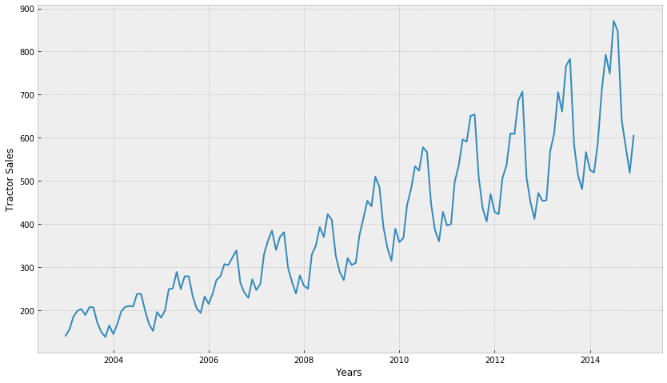

```python
# extract out the time-series
sales_ts = sales_data['Tractor-Sales']

_ = plt.figure(figsize=(14,8))
_ = plt.plot(sales_ts)
_ = plt.xlabel('Years')
_ = plt.ylabel('Tractor Sales')
```

### Plotting Rolling Statistics - Moving Average

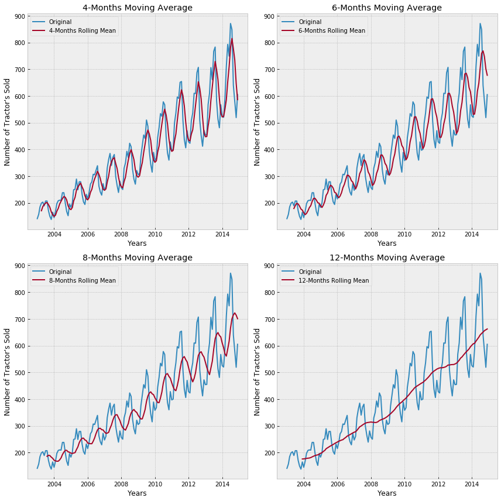

```python
plt.figure(figsize=(12,12))

for i, WinSize in enumerate([4,6,8,12]):
    MovingAvr = sales_ts.rolling(window=WinSize).mean()

    _ = plt.subplot(2,2,i+1)
    _ = plt.plot(sales_ts.index, sales_ts, label='Original')
    _ = plt.plot(sales_ts.index, MovingAvr, label='{}-Months Rolling Mean'.format(WinSize))
    _ = plt.xlabel("Years")
    _ = plt.ylabel("Number of Tractor's Sold")
    _ = plt.title("{}-Months Moving Average".format(WinSize))
    _ = plt.legend(loc='best')
plt.tight_layout()
# Discussion: As we could see in the above plots, 12-month moving average could produce a
# wrinkle free curve as desired. This on some level is expected since we are using month-wise
# data for our analysis and there is expected monthly-seasonal effect in our data.
```

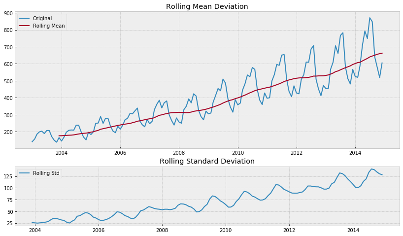

```
2003-01-01           NaN
2003-02-01           NaN
2003-03-01           NaN
2003-04-01           NaN
2003-05-01           NaN
2003-06-01           NaN
2003-07-01           NaN
2003-08-01           NaN
2003-09-01           NaN
2003-10-01           NaN
2003-11-01           NaN
2003-12-01    176.000000
2004-01-01    176.333333
2004-02-01    177.250000
2004-03-01    178.250000
Freq: MS, Name: Tractor-Sales, dtype: float64
```

```python
#Determing rolling statistics
WinSize = 12
rolmean = sales_ts.rolling(window=WinSize).mean()
rolstd = sales_ts.rolling(window=WinSize).std()

#Plot rolling statistics:
_ = plt.figure(figsize=(14,8))
grid = plt.GridSpec(3, 1, wspace=0.4, hspace=0.3)

_ = plt.subplot(grid[0:2, 0])
orig = plt.plot(sales_ts, label='Original')
mean = plt.plot(rolmean, label='Rolling Mean')
_ = plt.title('Rolling Mean Deviation')
_ = plt.legend(loc='best')

_ = plt.subplot(grid[2, 0])
std = plt.plot(rolstd, label = 'Rolling Std')
_ = plt.legend(loc='best')
_ = plt.title('Rolling Standard Deviation')
_ = plt.show(block=False)

rolmean.head(15) ## First WinSize values are NaN
```

```python
# Perform Dickey-Fuller test:
# adfuller?

dftest = adfuller(sales_ts, autolag='AIC')
print('Results of Dickey-Fuller Test:')
print(dftest)
print('********************************************* \n')

def printadfuller(dftest):
    dfoutput = pd.Series(dftest[0:4], index=['Test Statistic', 'p-value', '#lags Used',
                                             'Number of Observations Used'])
    for key, value in dftest[4].items():
        dfoutput['Critical Value (%s)'%key] = value
    print('Results of Dickey-Fuller Test: (clean display)')
    print(dfoutput)
    print('''\n
*** Note:
p-value>0.05 ==> null hypothesis is accepted ==> Data is non-stationary
''')

printadfuller(dftest)


### note: p-value>0.05 ==> null hypothesis is accepted ==> Data is non-stationary
```

```
Results of Dickey-Fuller Test:
(1.1088250591467386, 0.995291241524842, 14, 129, {'1%': -3.482087964046026, '5%': -2.8842185101614626, '10%': -2.578864381347275}, 1082.5357724796872)

Results of Dickey-Fuller Test: (clean display)
Test Statistic                   1.108825
p-value                          0.995291
#lags Used                      14.000000
Number of Observations Used    129.000000
Critical Value (1%)             -3.482088
Critical Value (5%)             -2.884219
Critical Value (10%)            -2.578864
dtype: float64


*** Note:
p-value>0.05 ==> null hypothesis is accepted ==> Data is non-stationary
```

```python
# Kwiatkowski-Phillips-Schmidt-Shin test for stationarity.
# kpss?
kpsstest = kpss(sales_ts, lags='auto')
print('Results of KPSS Test:')
print(kpsstest)
print('********************************************* \n')


#     kpss_stat (float) – The KPSS test statistic
#     p_value (float) – The p-value of the test. The p-value is interpolated from Table 1 in Kwiatkowski et al. (1992), and a boundary point is returned if the test statistic is outside the table of critical values, that is, if the p-value is outside the interval (0.01, 0.1).
#     lags (int) – The truncation lag parameter
#     crit (dict) – The critical values at 10%, 5%, 2.5% and 1%. Based on Kwiatkowski et al. (1992).
#     resstore ((optional) instance of ResultStore) – An instance of a dummy class with results attached as attributes


def printkpss(dftest):
    dfoutput = pd.Series(dftest[0:3], index=['Test Statistic', 'p-value', '#lags Used'])
    for key, value in dftest[3].items():
        dfoutput['Critical Value (%s)'%key] = value
    print('Results of KPSS Test: (clean display)')
    print(dfoutput)
    print('''\n
*** Note:
p-value>0.05 ==> null hypothesis is accepted ==> Data is stationary
''')

printkpss(kpsstest)
```

```
Results of KPSS Test:
(1.6340558059262322, 0.01, 8, {'10%': 0.347, '5%': 0.463, '2.5%': 0.574, '1%': 0.739})

Results of KPSS Test: (clean display)
Test Statistic           1.634056
p-value                  0.010000
#lags Used               8.000000
Critical Value (10%)     0.347000
Critical Value (5%)      0.463000
Critical Value (2.5%)    0.574000
Critical Value (1%)      0.739000
dtype: float64


*** Note:
p-value>0.05 ==> null hypothesis is accepted ==> Data is stationary
```

```
Year   2003  2004  2005  2006  2007  2008  2009  2010  2011  2012  2013  2014
Month
Jan     141   145   183   215   247   257   305   358   397   428   454   525
Feb     157   168   200   239   261   250   310   368   400   423   455   520
Mar     185   197   249   270   330   329   374   444   498   507   568   587
Apr     199   208   251   279   362   350   414   482   536   536   610   710
May     203   210   289   307   385   393   454   534   596   610   706   793
Jun     189   209   249   305   340   370   441   524   591   609   661   749
Jul     207   238   279   322   370   423   510   578   651   687   767   871
Aug     207   238   279   339   381   410   486   567   654   707   783   848
Sep     171   199   232   263   299   326   393   447   509   509   583   640
Oct     150   168   204   241   266   289   345   386   437   452   513   581
Nov     138   152   194   229   239   270   315   360   406   412   481   519
Dec     165   196   232   272   281   321   389   428   470   472   567   605
```

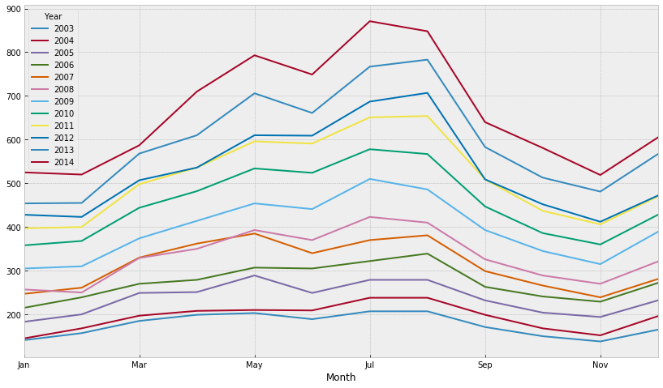

```python
# Seasonality – Time Series Decomposition
monthly_sales_data = pd.pivot_table(sales_data,
                                    values = "Tractor-Sales",
                                    columns = "Year",
                                    index = "Month",
                                    aggfunc=np.mean)
monthly_sales_data = monthly_sales_data.reindex(index = ['Jan','Feb','Mar', 'Apr', 'May',
                                                         'Jun', 'Jul', 'Aug', 'Sep', 'Oct',
                                                         'Nov', 'Dec'])
print(monthly_sales_data)

_ = monthly_sales_data.plot(figsize=(14,8))
```

```
Month  Jan  Feb  Mar  Apr  May  Jun  Jul  Aug  Sep  Oct  Nov  Dec
Year
2003   141  157  185  199  203  189  207  207  171  150  138  165
2004   145  168  197  208  210  209  238  238  199  168  152  196
2005   183  200  249  251  289  249  279  279  232  204  194  232
2006   215  239  270  279  307  305  322  339  263  241  229  272
2007   247  261  330  362  385  340  370  381  299  266  239  281
2008   257  250  329  350  393  370  423  410  326  289  270  321
2009   305  310  374  414  454  441  510  486  393  345  315  389
2010   358  368  444  482  534  524  578  567  447  386  360  428
2011   397  400  498  536  596  591  651  654  509  437  406  470
2012   428  423  507  536  610  609  687  707  509  452  412  472
2013   454  455  568  610  706  661  767  783  583  513  481  567
2014   525  520  587  710  793  749  871  848  640  581  519  605
```

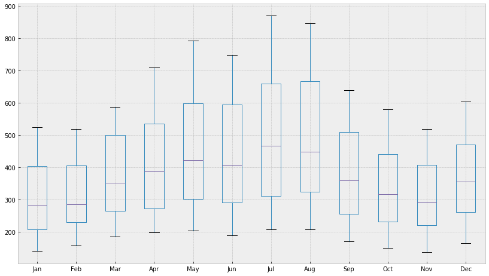

```python
### Yearly Sales

yearly_sales_data = pd.pivot_table(sales_data, values = "Tractor-Sales", columns = "Month",
                                   index = "Year")
yearly_sales_data = yearly_sales_data[['Jan','Feb','Mar', 'Apr', 'May', 'Jun', 'Jul', 'Aug',
                                       'Sep', 'Oct', 'Nov', 'Dec']]
print(yearly_sales_data)

_ = plt.figure(figsize=(14,8))
_ = yearly_sales_data.boxplot()
```

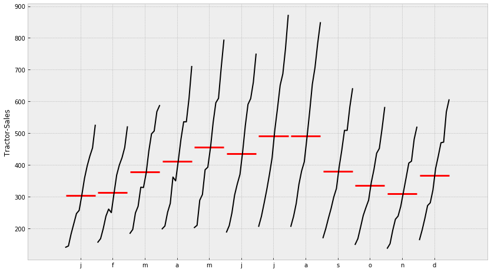

```python
# smt.graphics.month_plot?

fig = smt.graphics.month_plot(sales_ts, ylabel ='Tractor-Sales')
fig.set_figwidth(14)
fig.set_figheight(8)
```

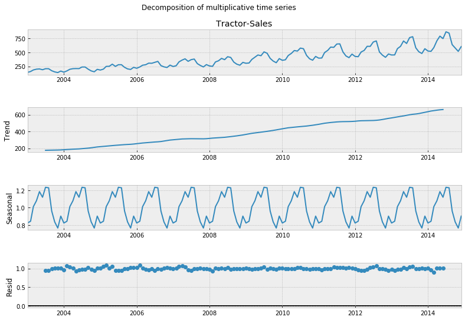

```python
# smt.seasonal_decompose?

decomposition = smt.seasonal_decompose(sales_ts, model='multiplicative')
fig = decomposition.plot()
fig.set_figwidth(12)
fig.set_figheight(8)
_ = fig.suptitle('Decomposition of multiplicative time series')
plt.show()
```

**Important Inferences**

- The tractor sales have been increasing without fail every year.
- July and August are the peak months for tractor sales and the variance and the mean value in July and August are also much higher than any of the other months.
- We can see a seasonal cycle of 12 months where the mean value of each month starts with a increasing trend in the beginning of the year and drops down towards the end of the year. We can see a seasonal effect with a cycle of 12 months.

```python
residuals = decomposition.resid ## Residuals
print('Number of missing values: {}'.format( residuals.isna().sum()))
print('\n')

residuals.dropna(inplace=True)

# Perform Dickey-Fuller test:
dftest = adfuller(residuals, autolag='AIC')
printadfuller(dftest)

print('\n')
# Perform KPSS test:
kpsstest = kpss(residuals, lags='auto')
printkpss(kpsstest)

## Both Tests: Data is stationary
```

```
Number of missing values: 12


Results of Dickey-Fuller Test: (clean display)
Test Statistic                -7.483168e+00
p-value                        4.713620e-11
#lags Used                     7.000000e+00
Number of Observations Used    1.240000e+02
Critical Value (1%)           -3.484220e+00
Critical Value (5%)           -2.885145e+00
Critical Value (10%)          -2.579359e+00
dtype: float64


*** Note:
p-value>0.05 ==> null hypothesis is accepted ==> Data is non-stationary



Results of KPSS Test: (clean display)
Test Statistic           0.036547
p-value                  0.100000
#lags Used               4.000000
Critical Value (10%)     0.347000
Critical Value (5%)      0.463000
Critical Value (2.5%)    0.574000
Critical Value (1%)      0.739000
dtype: float64


*** Note:
p-value>0.05 ==> null hypothesis is accepted ==> Data is stationary
```

#### Step 2: log transform data to make data stationary on variance

#### Step 3: Difference data to make data stationary on mean (remove trend)

#### Step 4: Difference log transform data to make data stationary on both mean and variance

```python
#boxcox?

boxcox(sales_ts)[1]


# y = (x**lmbda - 1) / lmbda,  for lmbda > 0
#     log(x),                  for lmbda = 0
```

```
0.13371391972000465
```

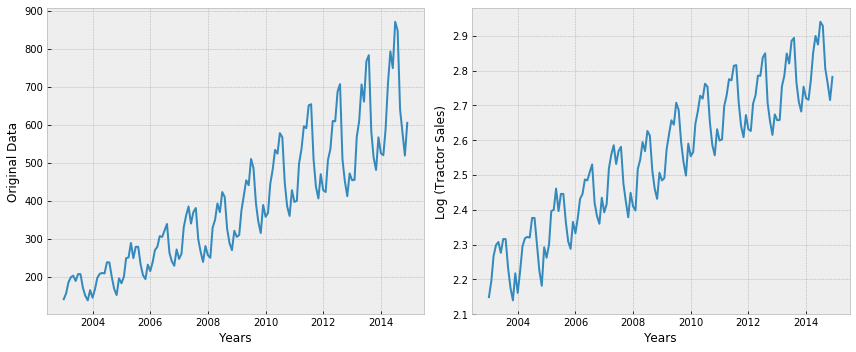

```python
# make the series stationary on variance through transforming the original series through
# log transform

_ = plt.figure(figsize=(12, 5))
_ = plt.subplot(1,2,1)
_ = plt.plot(sales_ts)
_ = plt.xlabel('Years')
_ = plt.ylabel('Original Data')
_ = plt.subplot(1,2,2)
_ = plt.plot(np.log10(sales_ts))
_ = plt.xlabel('Years')
_ = plt.ylabel('Log (Tractor Sales)')
_ = plt.tight_layout()
```

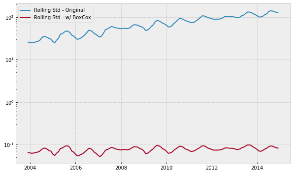

```python
#Determing rolling statistics
WinSize = 12
rolstd_woBOX = sales_ts.rolling(window=WinSize).std()
rolstd_wBOX = np.log10(sales_ts).rolling(window=WinSize).std()

#Plot rolling statistics:
_ = plt.figure(figsize=(10,6))
_ = plt.semilogy(rolstd_woBOX, label='Rolling Std - Original')
_ = plt.semilogy(rolstd_wBOX, label='Rolling Std - w/ BoxCox')
_ = plt.legend(loc='best')
```

```
Results of Dickey-Fuller Test: (clean display)
Test Statistic                  -2.716590
p-value                          0.071211
#lags Used                      12.000000
Number of Observations Used    119.000000
Critical Value (1%)             -3.486535
Critical Value (5%)             -2.886151
Critical Value (10%)            -2.579896
dtype: float64


*** Note:
p-value>0.05 ==> null hypothesis is accepted ==> Data is non-stationary
```

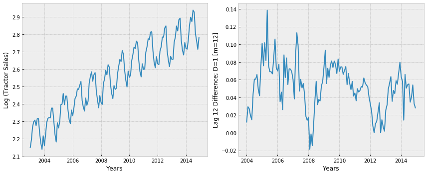

```python
#To make the series stationary by removing seasonality trend through 12st order
# differencing of the series

_ = plt.figure(figsize=(12, 5))
_ = plt.subplot(1,2,1)
_ = plt.plot(np.log10(sales_ts))
_ = plt.xlabel('Years')
_ = plt.ylabel('Log (Tractor Sales)')
_ = plt.subplot(1,2,2)
_ = plt.plot(np.log10(sales_ts).diff(periods=12))
_ = plt.xlabel('Years')
_ = plt.ylabel('Lag 12 Difference; D=1 [m=12]')
_ = plt.tight_layout()

printadfuller(adfuller(np.log10(sales_ts).diff(periods=12).dropna(),
                       autolag='AIC'))
```

```
Results of Dickey-Fuller Test: (clean display)
Test Statistic                  -2.680467
p-value                          0.077480
#lags Used                      14.000000
Number of Observations Used    128.000000
Critical Value (1%)             -3.482501
Critical Value (5%)             -2.884398
Critical Value (10%)            -2.578960
dtype: float64


*** Note:
p-value>0.05 ==> null hypothesis is accepted ==> Data is non-stationary
```

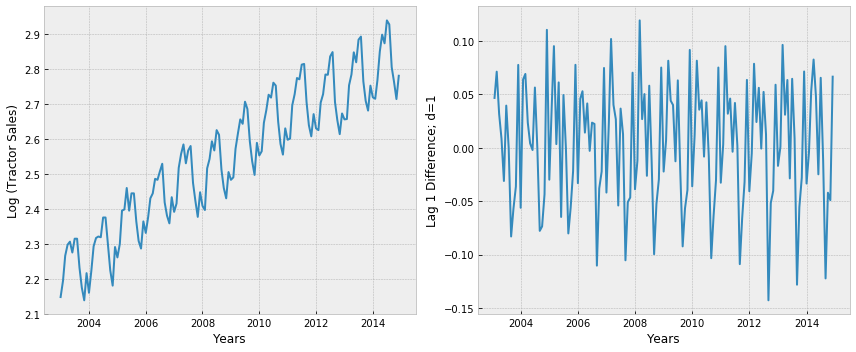

```python
#To make the series stationary by removing the upward trend through 1st order
# differencing of the series

_ = plt.figure(figsize=(12, 5))
_ = plt.subplot(1,2,1)
_ = plt.plot(np.log10(sales_ts))
_ = plt.xlabel('Years')
_ = plt.ylabel('Log (Tractor Sales)')
_ = plt.subplot(1,2,2)
_ = plt.plot(np.log10(sales_ts).diff(periods=1))
_ = plt.xlabel('Years')
_ = plt.ylabel('Lag 1 Difference; d=1')
_ = plt.tight_layout()


printadfuller(adfuller(np.log10(sales_ts).diff(periods=1).dropna(),
                       autolag='AIC'))
```

```
Results of Dickey-Fuller Test: (clean display)
Test Statistic                  -4.480962
p-value                          0.000213
#lags Used                      12.000000
Number of Observations Used    118.000000
Critical Value (1%)             -3.487022
Critical Value (5%)             -2.886363
Critical Value (10%)            -2.580009
dtype: float64


*** Note:
p-value>0.05 ==> null hypothesis is accepted ==> Data is non-stationary



Results of KPSS Test: (clean display)
Test Statistic           0.073023
p-value                  0.100000
#lags Used               3.000000
Critical Value (10%)     0.347000
Critical Value (5%)      0.463000
Critical Value (2.5%)    0.574000
Critical Value (1%)      0.739000
dtype: float64


*** Note:
p-value>0.05 ==> null hypothesis is accepted ==> Data is stationary
```

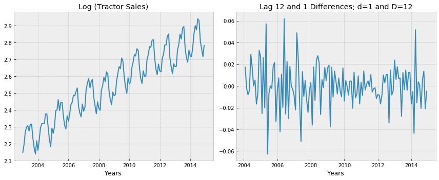

```python
_ = plt.figure(figsize=(12, 5))
_ = plt.subplot(1,2,1)
_ = plt.plot(np.log10(sales_ts))
_ = plt.xlabel('Years')
_ = plt.title('Log (Tractor Sales)')
_ = plt.subplot(1,2,2)
_ = plt.plot(np.log10(sales_ts).diff(periods=12).diff(periods=1))
_ = plt.xlabel('Years')
_ = plt.title('Lag 12 and 1 Differences; d=1 and D=12')
_ = plt.tight_layout()


printadfuller(adfuller(np.log10(sales_ts).diff(periods=12).diff(periods=1).dropna(),
                       autolag='AIC'))

print('\n')
printkpss(kpss(np.log10(sales_ts).diff(periods=12).diff(periods=1).dropna(), lags='auto' ))
```

#### Step 5: Plot ACF and PACF to identify potential AR and MA model

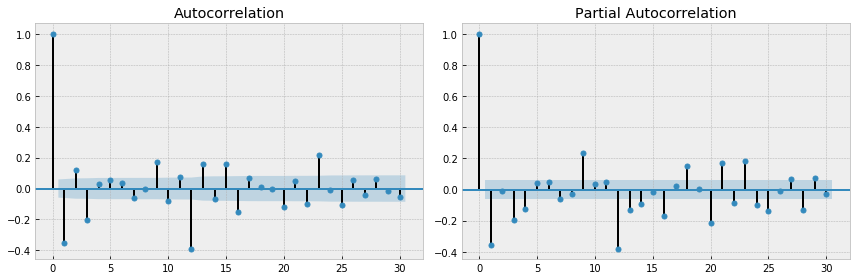

```python
# smt.graphics.plot_acf?
# smt.graphics.plot_pacf?

sales_ts_log = np.log10(sales_ts)
sales_ts_log.dropna(inplace=True)

sales_ts_log_diff = sales_ts_log.diff(periods=1)#.diff(periods=12) # same as
                                                #ts_log_diff = ts_log - ts_log.shift(periods=12)
sales_ts_log_diff = sales_ts_log.diff(periods=12)

sales_ts_log_diff = sales_ts_log.diff(periods=12).diff(periods=1)

sales_ts_log_diff.dropna(inplace=True)

# del fig, axes
fig, axes = plt.subplots(1, 2, sharey=False, sharex=False)
fig.set_figwidth(12)
fig.set_figheight(4)
_ = smt.graphics.plot_acf(sales_ts_log_diff, lags=30, ax=axes[0], alpha=0.5)
_ = smt.graphics.plot_pacf(sales_ts_log_diff, lags=30, ax=axes[1], alpha=0.5)
plt.tight_layout()
```

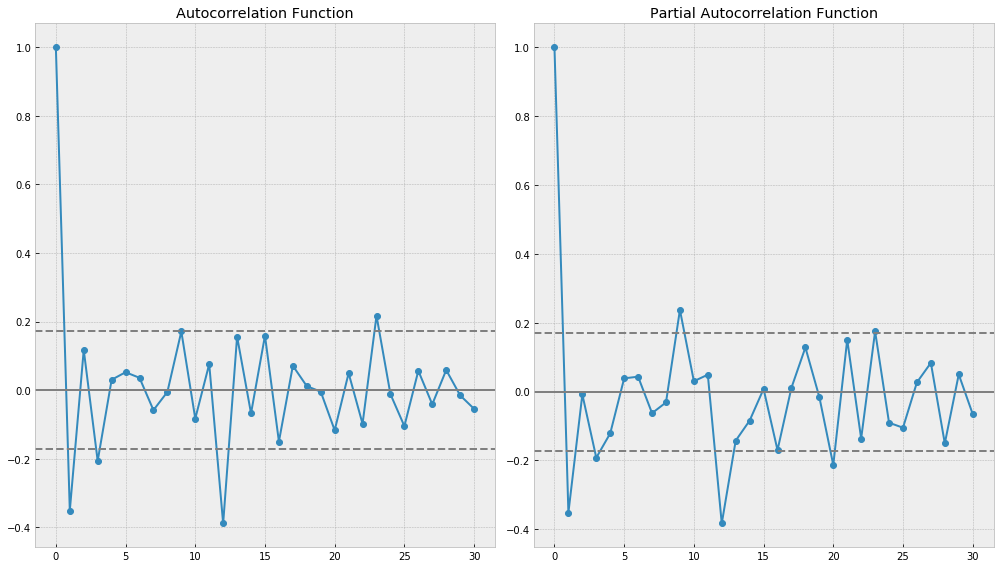

```python
# acf?
# pacf?

lag_acf = acf(sales_ts_log_diff, nlags=30, fft=True) # fft: If True, computes the ACF via FFT
lag_pacf = pacf(sales_ts_log_diff, nlags=30, method='ols')
numObs =  len(sales_ts_log_diff)

_ = plt.figure(figsize = (14,8))
#Plot ACF:
_ = plt.subplot(1,2,1)
_ = plt.plot(lag_acf,'-o')
_ = plt.axhline(y=0,linestyle='-',color='gray')
_ = plt.axhline(y=-1.96/np.sqrt(numObs),linestyle='--',color='gray')
_ = plt.axhline(y=1.96/np.sqrt(numObs),linestyle='--',color='gray')
_ = plt.title('Autocorrelation Function')

#Plot PACF:
_ = plt.subplot(1,2,2)
_ = plt.plot(lag_pacf,'-o')
_ = plt.axhline(y=0,linestyle='-',color='gray')
_ = plt.axhline(y=-1.96/np.sqrt(numObs),linestyle='--',color='gray')
_ = plt.axhline(y=1.96/np.sqrt(numObs),linestyle='--',color='gray')
_ = plt.title('Partial Autocorrelation Function')
_ = plt.tight_layout()
```

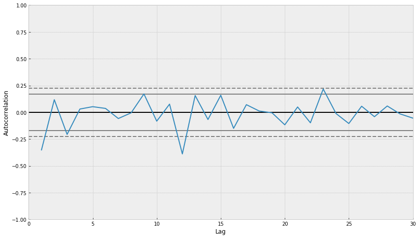

```python
_ = plt.figure(figsize=(14,8))
_ = pd.plotting.autocorrelation_plot(sales_ts_log_diff, linestyle='-')
_ = plt.xlim([0,30])
_ = plt.grid()
```

#### Step 6: Identification of best fit ARIMA model¶

```python
#Returns information criteria for many ARMA models
# smt.arma_order_select_ic?

res = smt.arma_order_select_ic(sales_ts_log, max_ar= 2, max_ma=3, ic= ['aic', 'bic'])
pd.DataFrame(res['aic'])
print('aic_min_order : {}'.format(res.aic_min_order))
print('\n')
pd.DataFrame(res['bic'])
print('bic_min_order : {}'.format(res.bic_min_order))


# See 'x13_arima_select_order' tp [P]erform automatic seasonal ARIMA order identification using x12/x13 ARIMA.
```

|  | 0 | 1 | 2 | 3 |
| --- | --- | --- | --- | --- |
| 0 | -56.965955 | -216.842877 | -312.933225 | -376.765107 |
| 1 | -412.047206 | -413.356382 | -411.387556 | -308.923639 |
| 2 | -413.348025 | -411.379110 | -409.607641 | -407.631571 |

```
aic_min_order : (1, 1)
```

|  | 0 | 1 | 2 | 3 |
| --- | --- | --- | --- | --- |
| 0 | -51.026329 | -207.933437 | -301.053972 | -361.916040 |
| 1 | -403.137766 | -401.477129 | -396.538489 | -291.104759 |
| 2 | -401.468772 | -396.530044 | -391.788761 | -386.842878 |

```
bic_min_order : (1, 0)
```

```python
# Define the p, d and q parameters to take any value between 0 and 1
p = d = q = range(0, 2)

# Generate all different combinations of p, d and q triplets
pdq = list(itertools.product(p, d, q))

# Generate all different combinations of seasonal p, q and q triplets
seasonal_pdq = [(x[0], x[1], x[2], 12) for x in list(itertools.product(p, d, q))]

print('p, d, q:')
print(pdq,'\n')
print('P, D, Q, m:')
print(seasonal_pdq)
```

```
p, d, q:
[(0, 0, 0), (0, 0, 1), (0, 1, 0), (0, 1, 1), (1, 0, 0), (1, 0, 1), (1, 1, 0), (1, 1, 1)]

P, D, Q, m:
[(0, 0, 0, 12), (0, 0, 1, 12), (0, 1, 0, 12), (0, 1, 1, 12), (1, 0, 0, 12), (1, 0, 1, 12), (1, 1, 0, 12), (1, 1, 1, 12)]
```

```python
# smt.statespace.SARIMAX?
```

```python
best_aic = np.inf
best_pdq = None
best_seasonal_pdq = None
temp_model = None

warnings.filterwarnings("ignore") # specify to ignore warning messages

for param in pdq:
    for param_seasonal in seasonal_pdq:

        try:
            temp_model = smt.statespace.SARIMAX(sales_ts_log,
                                             order = param,
                                             seasonal_order = param_seasonal,
                                             enforce_stationarity=True,
                                             enforce_invertibility=True)
            results = temp_model.fit()

            print("SARIMAX{}x{}12 - AIC: {:.2f}".format(param, param_seasonal, results.aic))
            if results.aic < best_aic:
                best_aic = results.aic
                best_pdq = param
                best_seasonal_pdq = param_seasonal
        except:
            #print("Unexpected error:", sys.exc_info()[0])
            continue
print("Best SARIMAX{}x{}12 model - AIC: {:.2f}".format(best_pdq, best_seasonal_pdq, best_aic))

# (0, 1, 1)(0, 1, 1, 12): AIC =  -702.7798971378229
# (1, 1, 0)(1, 1, 0, 12): AIC =  -694.7833987129003

# (1, 1, 0)(1, 0, 1, 12): AIC:   -730.788765818175
# (1, 1, 1)(1, 0, 1, 12): AIC =  -732.1110947137493
# (0, 1, 1)(1, 0, 1, 12): AIC =  -733.7733673716689 <== Best Model
```

```
SARIMAX(0, 0, 0)x(0, 0, 0, 12)12 - AIC: 680.87
SARIMAX(0, 0, 0)x(0, 0, 1, 12)12 - AIC: 524.70
SARIMAX(0, 0, 0)x(0, 1, 0, 12)12 - AIC: -372.96
SARIMAX(0, 0, 0)x(0, 1, 1, 12)12 - AIC: -417.41
SARIMAX(0, 0, 0)x(1, 0, 0, 12)12 - AIC: -314.50
SARIMAX(0, 0, 0)x(1, 0, 1, 12)12 - AIC: -358.93
SARIMAX(0, 0, 0)x(1, 1, 0, 12)12 - AIC: -464.93
SARIMAX(0, 0, 0)x(1, 1, 1, 12)12 - AIC: -521.70
SARIMAX(0, 0, 1)x(0, 0, 0, 12)12 - AIC: 489.66
SARIMAX(0, 0, 1)x(0, 0, 1, 12)12 - AIC: 332.74
SARIMAX(0, 0, 1)x(0, 1, 0, 12)12 - AIC: -479.06
SARIMAX(0, 0, 1)x(0, 1, 1, 12)12 - AIC: -497.69
SARIMAX(0, 0, 1)x(1, 0, 0, 12)12 - AIC: -409.06
SARIMAX(0, 0, 1)x(1, 0, 1, 12)12 - AIC: -368.13
SARIMAX(0, 0, 1)x(1, 1, 0, 12)12 - AIC: -519.92
SARIMAX(0, 0, 1)x(1, 1, 1, 12)12 - AIC: -573.83
SARIMAX(0, 1, 0)x(0, 0, 0, 12)12 - AIC: -414.12
SARIMAX(0, 1, 0)x(0, 0, 1, 12)12 - AIC: -524.37
SARIMAX(0, 1, 0)x(0, 1, 0, 12)12 - AIC: -653.88
SARIMAX(0, 1, 0)x(0, 1, 1, 12)12 - AIC: -686.40
SARIMAX(0, 1, 0)x(1, 0, 0, 12)12 - AIC: -690.95
SARIMAX(0, 1, 0)x(1, 0, 1, 12)12 - AIC: -719.16
SARIMAX(0, 1, 0)x(1, 1, 0, 12)12 - AIC: -676.22
SARIMAX(0, 1, 0)x(1, 1, 1, 12)12 - AIC: -684.41
SARIMAX(0, 1, 1)x(0, 0, 0, 12)12 - AIC: -414.71
SARIMAX(0, 1, 1)x(0, 0, 1, 12)12 - AIC: -522.80
SARIMAX(0, 1, 1)x(0, 1, 0, 12)12 - AIC: -669.79
SARIMAX(0, 1, 1)x(0, 1, 1, 12)12 - AIC: -702.79
SARIMAX(0, 1, 1)x(1, 0, 0, 12)12 - AIC: -703.53
SARIMAX(0, 1, 1)x(1, 0, 1, 12)12 - AIC: -733.77
SARIMAX(0, 1, 1)x(1, 1, 0, 12)12 - AIC: -697.10
SARIMAX(0, 1, 1)x(1, 1, 1, 12)12 - AIC: -701.29
SARIMAX(1, 0, 0)x(0, 0, 0, 12)12 - AIC: -407.48
SARIMAX(1, 0, 0)x(0, 0, 1, 12)12 - AIC: -514.14
SARIMAX(1, 0, 0)x(0, 1, 0, 12)12 - AIC: -659.36
SARIMAX(1, 0, 0)x(0, 1, 1, 12)12 - AIC: -688.12
SARIMAX(1, 0, 0)x(1, 0, 0, 12)12 - AIC: -685.75
SARIMAX(1, 0, 0)x(1, 0, 1, 12)12 - AIC: -715.91
SARIMAX(1, 0, 0)x(1, 1, 0, 12)12 - AIC: -679.22
SARIMAX(1, 0, 0)x(1, 1, 1, 12)12 - AIC: -685.71
```

[output cut: 10 more lines]

```
SARIMAX(1, 1, 0)x(0, 1, 0, 12)12 - AIC: -669.12
SARIMAX(1, 1, 0)x(0, 1, 1, 12)12 - AIC: -701.03
SARIMAX(1, 1, 0)x(1, 0, 0, 12)12 - AIC: -703.51
SARIMAX(1, 1, 0)x(1, 0, 1, 12)12 - AIC: -732.73
SARIMAX(1, 1, 0)x(1, 1, 0, 12)12 - AIC: -694.78
SARIMAX(1, 1, 0)x(1, 1, 1, 12)12 - AIC: -699.28
SARIMAX(1, 1, 1)x(0, 0, 0, 12)12 - AIC: -412.72
SARIMAX(1, 1, 1)x(0, 0, 1, 12)12 - AIC: -520.81
SARIMAX(1, 1, 1)x(0, 1, 0, 12)12 - AIC: -667.14
SARIMAX(1, 1, 1)x(0, 1, 1, 12)12 - AIC: -699.09
SARIMAX(1, 1, 1)x(1, 0, 0, 12)12 - AIC: -701.55
SARIMAX(1, 1, 1)x(1, 0, 1, 12)12 - AIC: -732.14
SARIMAX(1, 1, 1)x(1, 1, 0, 12)12 - AIC: -695.14
SARIMAX(1, 1, 1)x(1, 1, 1, 12)12 - AIC: -698.71
Best SARIMAX(0, 1, 1)x(1, 0, 1, 12)12 model - AIC: -733.77
```

```python
# fitting a ARIMAX(0, 1, 1)x(0, 1, 1)12 instead of the best SARIMAX model

new_param_order = (0, 1, 1)
new_param_seasonal_order = (0, 1, 1, 12)
new_model = smt.statespace.SARIMAX(sales_ts_log,
                                      order=new_param_order,
                                      seasonal_order=new_param_seasonal_order,
                                      enforce_stationarity=True,
                                      enforce_invertibility=True )
new_results = new_model.fit()
print("SARIMAX{}x{}12 model - AIC: {:.2f}".format(new_param_order,
                                                  new_param_seasonal_order, new_results.aic))

## Discussion: the 1st model is better
```

```
SARIMAX(0, 1, 1)x(0, 1, 1, 12)12 model - AIC: -702.79
```

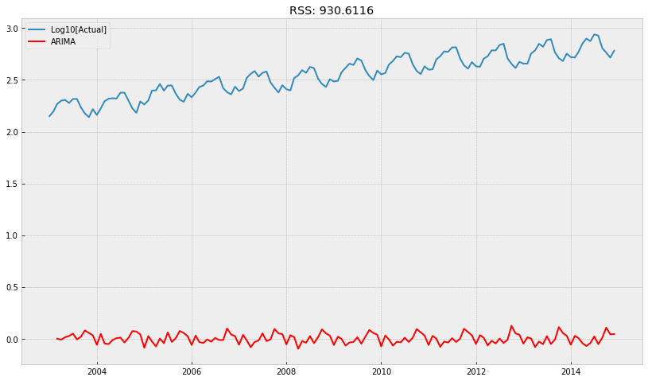

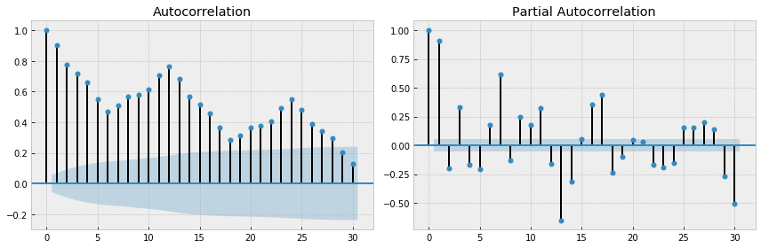

```python
# from statsmodels.tsa.arima_model import ARIMA
#ARIMA?

model_ARIMA = smt.ARIMA(sales_ts_log, order=(2, 2, 1))
results_ARIMA = model_ARIMA.fit()
#results_ARIMA.fittedvalues?

Residuals = results_ARIMA.fittedvalues-sales_ts_log
Residuals.dropna(inplace=True)

_ = plt.figure(figsize = (14,8))
_ = plt.plot(sales_ts_log,label='Log10[Actual]')
_ = plt.plot(results_ARIMA.fittedvalues, color='red', label='ARIMA')
_ = plt.title('RSS: %.4f'% sum(Residuals**2))
_ = plt.legend()


fig, axes = plt.subplots(1, 2, sharey=False, sharex=False)
fig.set_figwidth(12)
fig.set_figheight(4)
_ = smt.graphics.plot_acf(Residuals, lags=30, ax=axes[0], alpha=0.5)
_ = smt.graphics.plot_pacf(Residuals, lags=30, ax=axes[1], alpha=0.5)
plt.tight_layout()
```

#### Step 7: Predict sales on in-sample date using the best fit ARIMA model

```python
# Best SARIMAX(0, 1, 1)x(1, 0, 1, 12)12 model - AIC:-733.7733673716689

best_model = smt.statespace.SARIMAX(sales_ts_log,
                                      order=(0, 1, 1),
                                      seasonal_order=(1, 0, 1, 12),
                                      enforce_stationarity=True,
                                      enforce_invertibility=True)
best_results = best_model.fit()

print(best_results.summary().tables[0])
print(best_results.summary().tables[1])
```

```
                                     SARIMAX Results
==========================================================================================
Dep. Variable:                      Tractor-Sales   No. Observations:                  144
Model:             SARIMAX(0, 1, 1)x(1, 0, 1, 12)   Log Likelihood                 370.887
Date:                            Tue, 18 Aug 2020   AIC                           -733.775
Time:                                    22:34:31   BIC                           -721.923
Sample:                                01-01-2003   HQIC                          -728.959
                                     - 12-01-2014
Covariance Type:                              opg
==========================================================================================
==============================================================================
                 coef    std err          z      P>|z|      [0.025      0.975]
------------------------------------------------------------------------------
ma.L1         -0.3577      0.069     -5.202      0.000      -0.493      -0.223
ar.S.L12       0.9933      0.006    176.627      0.000       0.982       1.004
ma.S.L12      -0.5537      0.097     -5.738      0.000      -0.743      -0.365
sigma2         0.0003   2.73e-05      9.222      0.000       0.000       0.000
==============================================================================
```

```
Residuals:
2003-01-01    2.149219
2003-02-01    0.046681
Freq: MS, dtype: float64

Actual:
2003-01-01    2.149219
2003-02-01    2.195900
Freq: MS, Name: Tractor-Sales, dtype: float64
```

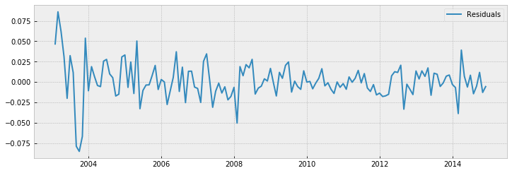

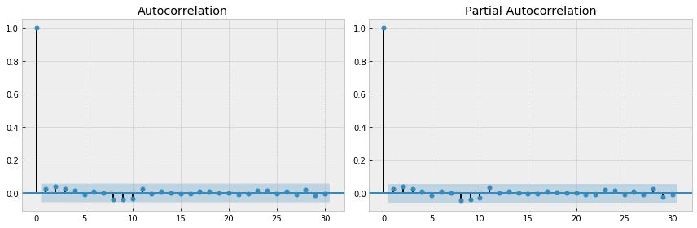

```python
## Review model residuals
best_results_residual = best_results.resid

print('Residuals:')
print(best_results_residual.head(2))
print('\nActual:')
print(sales_ts_log.head(2))

_ = plt.figure(figsize = (12,4))
_ = plt.plot(best_results_residual[1:],label='Residuals')
_ = plt.legend()



fig, axes = plt.subplots(1, 2, sharey=False, sharex=False)
fig.set_figwidth(12)
fig.set_figheight(4)
_ = smt.graphics.plot_acf(best_results_residual, lags=30, ax=axes[0], alpha=0.5)
_ = smt.graphics.plot_pacf(best_results_residual, lags=30, ax=axes[1], alpha=0.5)
plt.tight_layout()
```

```python
# Ljung-Box test for no autocorrelation
# acorr_ljungbox?

a, pvalue  = acorr_ljungbox(best_results_residual, lags = 10)
pvalue

## The Residuals are independently distributed
# p-value>0.05 ==> null hypothesis is accepted ==> The data are independently distributed
```

```
array([0.7643485 , 0.84792982, 0.93282544, 0.97713272, 0.99298375,
       0.99785046, 0.99944757, 0.99943679, 0.99949065, 0.9996898 ])
```

```python
# best_results.predict?  #In-sample prediction and out-of-sample forecasting
# best_results.forecast? #Out-of-sample forecasts

# best_results.get_forecast?
# best_results.get_prediction?
```

```
The Mean Squared Error of our forecasts is 0.0011
```

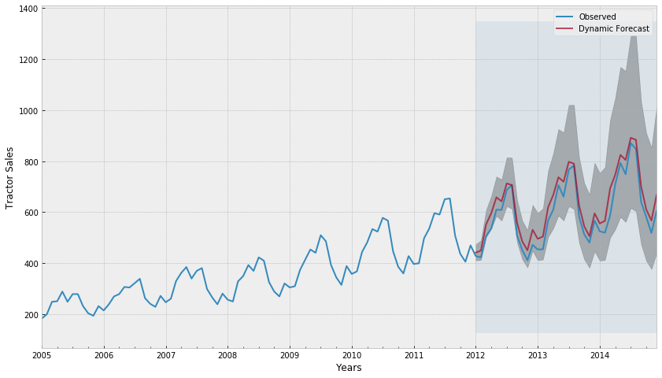

```python
pred_dynamic = best_results.get_prediction(start=pd.to_datetime('2012-01-01'), dynamic=True,
                                           full_results=True)

#Note:  The dynamic=True argument: a better representation of our true predictive power
#can be obtained using dynamic forecasts. In this case, we only use information from the time
#series up to a certain point, and after that, forecasts are generated using values from
#previous forecasted time points.


#pred_dynamic.conf_int?
#pred_dynamic.predicted_mean?

# Extract the predicted and true values of our time series
sales_ts_forecasted_dynamic = pred_dynamic.predicted_mean

# Extract the cI
pred_dynamic_ci = np.power(10, pred_dynamic.conf_int())

# Extract Actual values
sales_ts_truth = sales_ts_log['2012-01-01':]

# Compute the mean square error of one-step ahead forecasts
mse = ((sales_ts_forecasted_dynamic - sales_ts_truth) ** 2).mean()
print('The Mean Squared Error of our forecasts is {}'.format(round(mse, 4)))

_ = plt.figure(figsize=(14, 8))
_ = axis = sales_ts['2005':].plot(label='Observed')
_ = np.power(10, sales_ts_forecasted_dynamic).plot(ax=axis, label='Dynamic Forecast', alpha=0.7)
_ = axis.fill_between(pred_dynamic_ci.index, pred_dynamic_ci.iloc[:, 0],
                      pred_dynamic_ci.iloc[:, 1],
                      color='k', alpha=.25)
_ = axis.fill_betweenx(axis.get_ylim(), pd.to_datetime('2012-01-01'),
                       sales_ts.index[-1], alpha=.1,
                       zorder=-1)
_ = axis.set_xlabel('Years')
_ = axis.set_ylabel('Tractor Sales')
_ = plt.legend(loc='best')
_ = plt.show()
_ = plt.close()
```

```
The Mean Squared Error of our forecasts is 0.0002
```

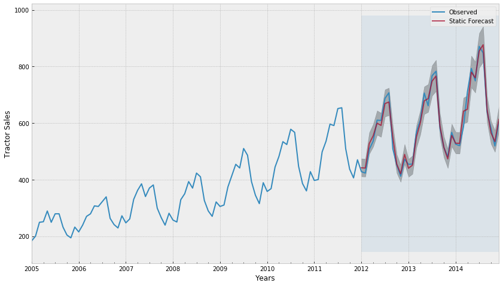

```python
pred_static = best_results.get_prediction(start=pd.to_datetime('2012-01-01'), dynamic=False,
                                           full_results=True)

#Note:  The dynamic=False argument ensures that we produce one-step ahead forecasts,
#meaning that forecasts at each point are generated using the full history up to that point

# Extract the predicted and true values of our time series
sales_ts_forecasted_static = pred_static.predicted_mean

# Extract the cI
pred_static_ci = np.power(10, pred_static.conf_int())

# Extract Actual values
sales_ts_truth = sales_ts_log['2012-01-01':]

# Compute the mean square error of one-step ahead forecasts
mse = ((sales_ts_forecasted_static - sales_ts_truth) ** 2).mean()
print('The Mean Squared Error of our forecasts is {}'.format(round(mse, 4)))

_ = plt.figure(figsize=(14, 8))
axis = sales_ts['2005':].plot(label='Observed')
_ = np.power(10, sales_ts_forecasted_static).plot(ax=axis, label='Static Forecast', alpha=0.7)
_ = axis.fill_between(pred_static_ci.index, pred_static_ci.iloc[:, 0]
                      , pred_static_ci.iloc[:, 1],
                  color='k', alpha=.25)
_ = axis.fill_betweenx(axis.get_ylim(), pd.to_datetime('2012-01-01'), sales_ts.index[-1], alpha=.1,
                   zorder=-1)



_ = axis.set_xlabel('Years')
_ = axis.set_ylabel('Tractor Sales')
_ = plt.legend(loc='best')
_ = plt.show()
_ = plt.close()
```

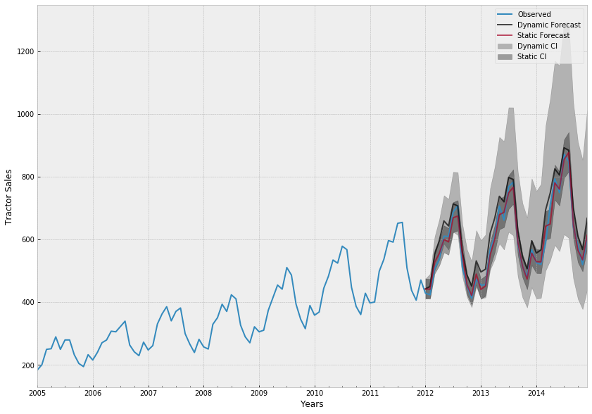

```python
_ = plt.figure(figsize=(14, 10))
axis = sales_ts['2005':].plot(label='Observed')
_ = np.power(10, sales_ts_forecasted_dynamic).plot(ax=axis, label='Dynamic Forecast',
                                                   color='k', alpha=0.7)
_ = np.power(10, sales_ts_forecasted_static).plot(ax=axis, label='Static Forecast',
                                                  alpha=0.7)
_ = axis.fill_between(pred_dynamic_ci.index, pred_dynamic_ci.iloc[:, 0]
                      , pred_dynamic_ci.iloc[:, 1],
                  color='k', alpha=.25, label='Dynamic CI')
_ = axis.fill_between(pred_static_ci.index, pred_static_ci.iloc[:, 0]
                      , pred_static_ci.iloc[:, 1],
                  color='k', alpha=.35, label='Static CI')

_ = axis.set_xlabel('Years')
_ = axis.set_ylabel('Tractor Sales')
_ = plt.legend(loc='best')
_ = plt.show()
_ = plt.close()
```

```python
mse = ((sales_ts_forecasted_dynamic - sales_ts_truth) ** 2).mean()
print('The Mean Squared Error of our forecasts is {}'.format(round(mse, 4)))

from sklearn.metrics import mean_squared_error
mse_sklearn = mean_squared_error(sales_ts_forecasted_dynamic,sales_ts_truth)
print('sklearn - The Mean Squared Error of our forecasts is {}'.format(round(mse_sklearn, 4)))
```

```
The Mean Squared Error of our forecasts is 0.0011
sklearn - The Mean Squared Error of our forecasts is 0.0011
```

#### Step 9: Plot ACF and PACF for residuals of ARIMA model to ensure no more information is left for extraction

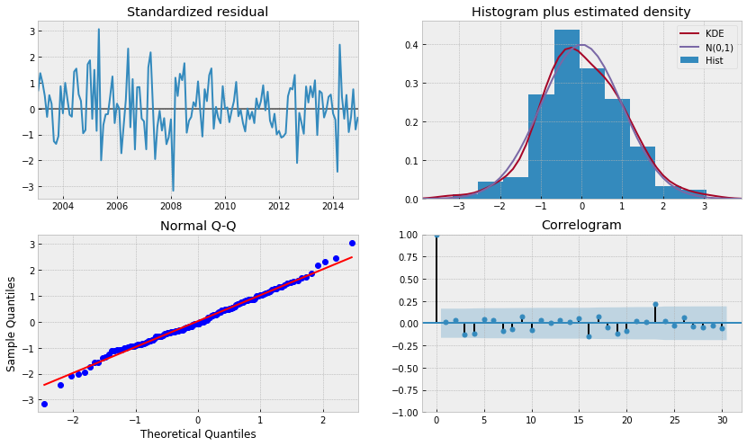

```python
_ = best_results.plot_diagnostics(lags=30, figsize=(14,8))
# plt.show()

# best_results.plot_diagnostics?


# Discussion
# 1) The KDE plot of the residuals on the top right is almost similar with the normal
#distribution.

# 2) The qq-plot on the bottom left shows that the ordered distribution of residuals (blue dots)
# follows the linear trend of the samples taken from a standard normal distribution
# with N(0, 1). Again, this is a strong indication that the residuals are normally distributed.

# 3) The residuals over time (top left plot) don't display any obvious seasonality and appear to
# be white noise. This is confirmed by the autocorrelation (i.e. correlogram) plot on the
# bottom right, which shows that the time series residuals have low correlation with lagged
# versions of itself.
```